# Breast Cancer Classification

# Explore the data

Now that I’ve loaded in the data, I’m ready to explore it.

First, a few questions arose in my mind, including whether or not there were repeated entries for patients.

The following table counts the number of time each patient ID (`patient_nbr`) appears in the data. There seems to be one patient who has 40 encounters, and a bunch of patients who had over 20 encounters.

```r
diabetic_clean %>%
  count(patient_nbr) %>%
  arrange(desc(n))
```

```
## # A tibble: 71,518 x 2
##    patient_nbr     n
##          <dbl> <int>
##  1    88785891    40
##  2    43140906    28
##  3     1660293    23
##  4    23199021    23
##  5    88227540    23
##  6    23643405    22
##  7    84428613    22
##  8    92709351    21
##  9    23398488    20
## 10    29903877    20
## # … with 71,508 more rows
```

I can also visualize these counts as a histogram, which shows that most patients have only 1 encounter in the data.

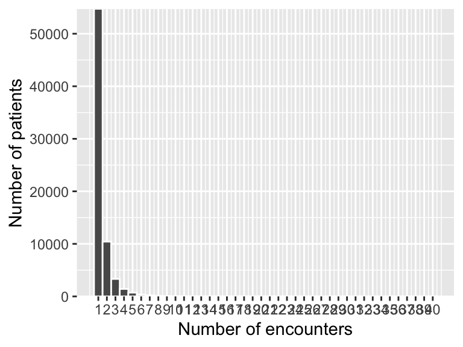

```r
diabetic_clean %>%
  count(patient_nbr) %>%
  arrange(desc(n)) %>%
  ggplot() +
  geom_histogram(aes(x = n), binwidth = 1, col = "white") +
  scale_x_continuous("Number of encounters", breaks = 1:40) +
  scale_y_continuous("Number of patients", expand = c(0, 0))
```

```r
  theme_classic()
```

[output not shown]

[output cut: 356 more lines]

[output not shown]

I’m interested in predicting readmission, so I’m interested to see whether any of the features appear to have any relationship with readmission. I do this by comparing the values of each variable.

Since my outcome is binary (readmitted within 30 days or not), I will use boxplots to examine any difference in distribution of each numeric and continuous feature across. If you were comparing two continuous variables, scatterplots would be more meaningful, but boxplots are great for when one variable is continuous and the other is binary or categorical (with many categories).

The code to make each of these would look as follows:

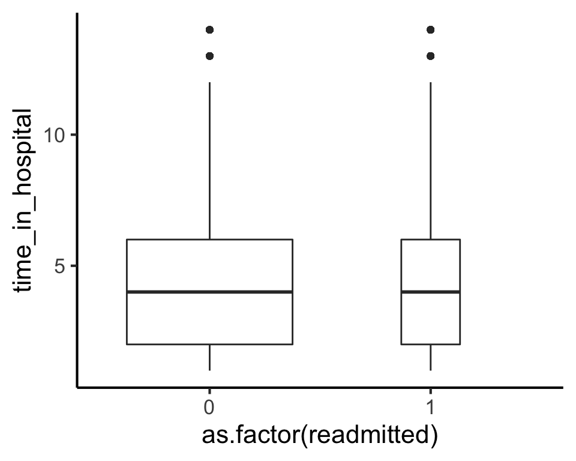

```r
diabetic_clean %>%
  ggplot() +
  geom_boxplot(aes(x = as.factor(readmitted), y = time_in_hospital),
               varwidth = TRUE) +
  theme_classic(base_size = 16) # increase font size and remove grid background
```

I like to vary the width of my boxplots based on how many people/observations are in each group.

There doesn’t seem to be a big difference between the amount of time spent in hospital for the readmitted and non-readmitted groups.

Since I don’t want to repeat myself by copy and pasting this code, I’m going to write a function that will do it for me. The body of the function `plotBoxplots` below is exactly the same as the code above, except I replaced `y = time_in_hospital` with `y = {{ variable }}`, where `variable` is the argument of the function. These curly braces correspond to “tidy evaluation”, that allows for us to use the tidyverse method of referring to columns using their *unquoted* names.

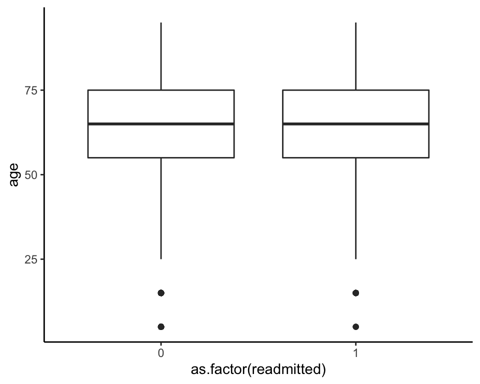

```r
plotBoxplots <- function(variable) {
  diabetic_clean %>%
  ggplot() +
  geom_boxplot(aes(x = as.factor(readmitted), y = {{ variable }})) +
  theme_classic() # increase font size and remove grid background
}
plotBoxplots(age)
```

If you want to use quoted names (e.g. because you want to add a title that uses the variable name), there is a slight variation that you can use, where you replace `{{ variable }}` with `.data[[variable]]`, since the data inside any tidyverse function can be accessed using the `.data` placeholder, and we are accessing the column called whatever we assigned `variable` to:

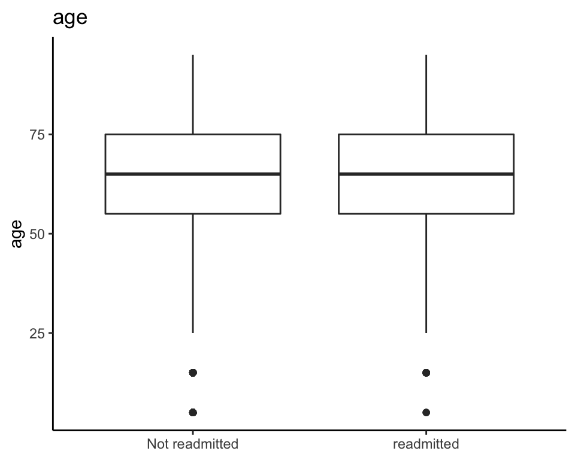

```r
plotBoxplotsCharacter <- function(variable) {
  diabetic_clean %>%
    ggplot() +
    geom_boxplot(aes(x = as.factor(readmitted), y = .data[[variable]])) +
    theme_classic() + # increase font size and remove grid background
    ggtitle(variable) +
    scale_x_discrete(NULL, labels = c("Not readmitted", "readmitted"))
}
plotBoxplotsCharacter("age")
```

So then we can use a map function to generate a list of plots.

```r
boxplot_list <- diabetic_clean %>%
  # remove the variables we don't want to plot
  select_if(is.numeric) %>%
  select(-patient_nbr, -encounter_id, -readmitted) %>%
  colnames() %>%
  # apply the plotBoxplotsCharacter function to each column name
  map(plotBoxplotsCharacter)
```

And we can plot that list of plots using `grid.arrange`.

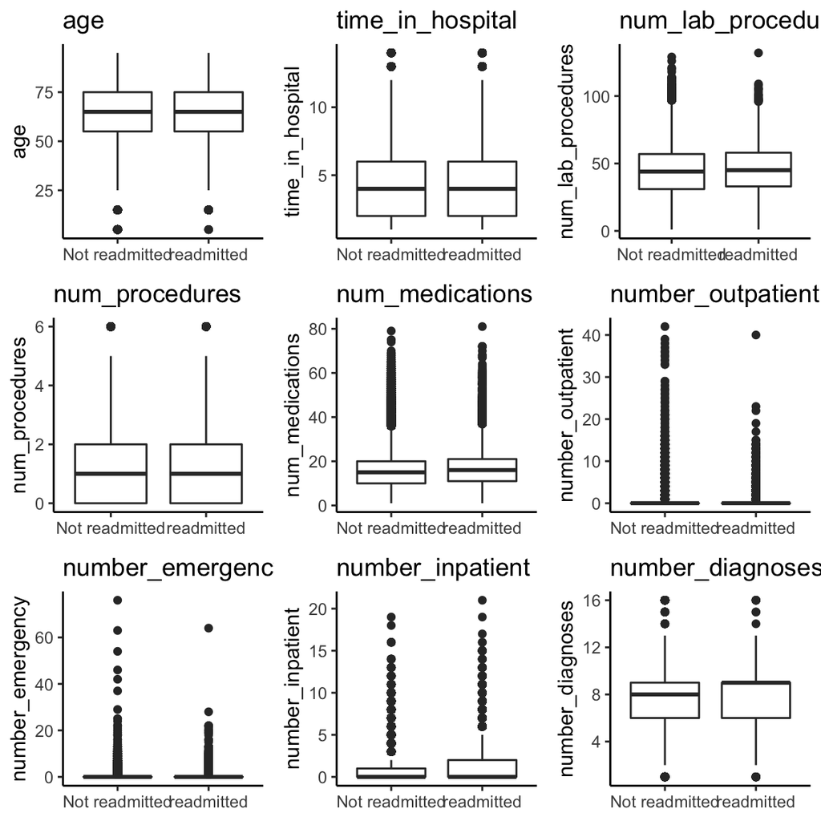

```r
gridExtra::grid.arrange(grobs = boxplot_list)
```

There are also a lot of categorical variables that I’d like to explore.